# Distributional Consequences of Climate Policy- ESM 204 Assignment 3

Sam Rozal, Hollie Pennington, Abigail Sanford

May 12th, 2022

```r
knitr::opts_chunk$set(echo = TRUE, message = FALSE, warning = FALSE)
library(tidyverse)
library(rootSolve)
library(janitor)
library(here)
```

```r
df <- read_csv(here("data","HW3_data.csv")) %>%
  select(-1) %>%
  clean_names()
```

Last year, the Biden Administration assembled an Inter-agency Working Group (IWG) tasked with updating the United States Government’s Social Cost of Carbon (SCC), which has not been comprehensively updated since 2010. The Administration has also called on government agencies to address environmental justice, racism, and equity concerns when considering policies designed to mitigate climate change.

While the Interagency Working Group develops a new SCC, the Biden Administration’s “interim” value is $51 per metric ton of CO2. The electricity sector is the second largest source of greenhouse gas emissions in the U.S. (after transportation). In this homework, you will consider the distributional consequences of imposing a household electricity tax based on the SCC to address the climate change problem.

We recommend using R and writing functions to compute your answers wherever possible. Use the following set of facts:

• Consumers can be separated into two income groups: “high” and “low.” The data set provides price (in $) and quantity (in kWh) estimates of demand per month for the two groups. Run linear regressions (with an intercept) to estimate the demand curves for “high” and “low” income consumers. • Initially, there is no tax on electricity consumption. • The current electricity price (without any taxes) is $.10 per kWh. • The marginal cost of producing a kWh of electricity is linear and has a price-intercept of 0.

# Question 1

One kWh of electricity emits 0.85 pounds of CO2. Assuming that the interim SCC correctly reflects the total social cost of one metric ton of CO2, what is the marginal external cost per kwH of electricity?

To find the MEC we use metric conversion to go from $/ton to cents/kWh:

- (5,100 cents/ 1 metric ton)(1 metric ton/2,205 lbs)(0.85lbs/1kWh)= 1.96 cents/kWh

The marginal external social cost of carbon is **$0.02/kWh**

# Question 2

What is the aggregate monthly demand curve for electricity? What is the supply curve for electricity? What is the “benefit” to consumers under the status quo? What is the “benefit” to producers under the status quo? What is the environmental cost under the status quo?

```r
model_demand_l <- lm(price_cents  ~ q_low_kwh, data=df)
model_demand_h <- lm(price_cents ~ q_high_kwh, data=df)
```

Equation of lines:

- Low income demand curve: P = 23.4 - 0.00011Q
- High income demand curve: P= 31.6 - 0.000052Q

```r
# need to rearrange the parameter to get Q(P)!
#Qgg = Qlow(P) + Qlow(h)

# Importantly, since they-intercepts are different, we know that Qagg(P) will have a kink. I include an ifelse() statement to take
# care of the kink.
```

```r
# define a function to get demand

demand <- function(p, model){
  q <- (p - model$coefficients[[1]])/model$coefficients[[2]]
  q <- ifelse(q<0,0,q)
  return(q)
}
```

```r
# for each p level, return estimated aggregate demand
demand_agg <- function(p){
  q <- demand(p, model_demand_l) + demand(p, model_demand_h)
  return(q)
}
```

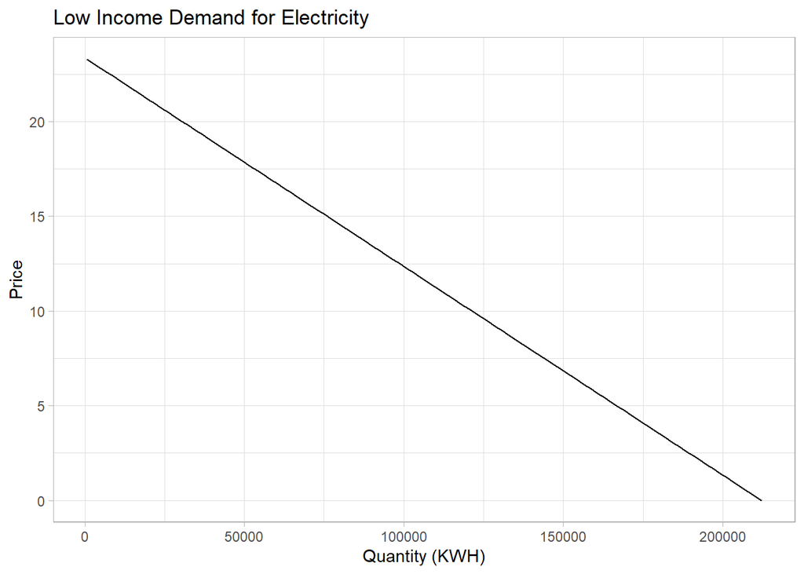

```r
price_low = seq(0, 23.3, length.out = 100)
demand_low <- demand(price_low, model_demand_l)

low_demand <- map(price_low,demand_low) %>% unlist()

df_2 <- tibble(demand_low = demand_low, price_low = price_low)

ggplot(df_2, aes(demand_low, price_low)) +
  geom_line() +
  labs(title = "Low Income Demand for Electricity", x = "Quantity (KWH)", y = "Price") +
  theme_light()
```

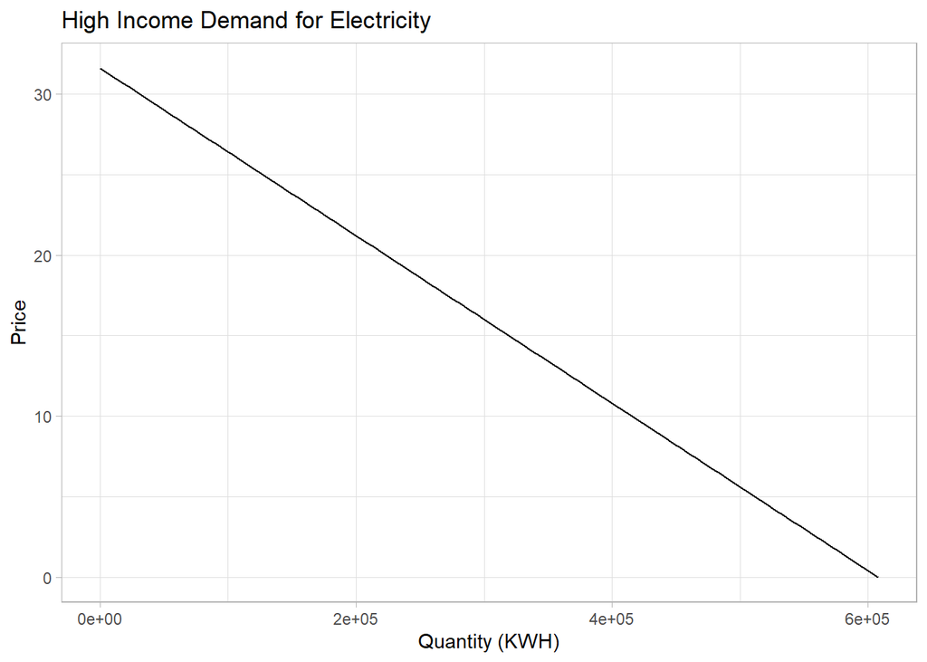

```r
price_high = seq(0, 31.6, length.out = 100)
demand_high <- demand(price_high, model_demand_h)

high_demand <- map(price_high,demand_high) %>% unlist()

df_3 <- tibble(demand_high = demand_high, price_high = price_high)

ggplot(df_2, aes(demand_high, price_high)) +
  geom_line() +
  labs(title = "High Income Demand for Electricity", x = "Quantity (KWH)", y = "Price") +
  theme_light()
```

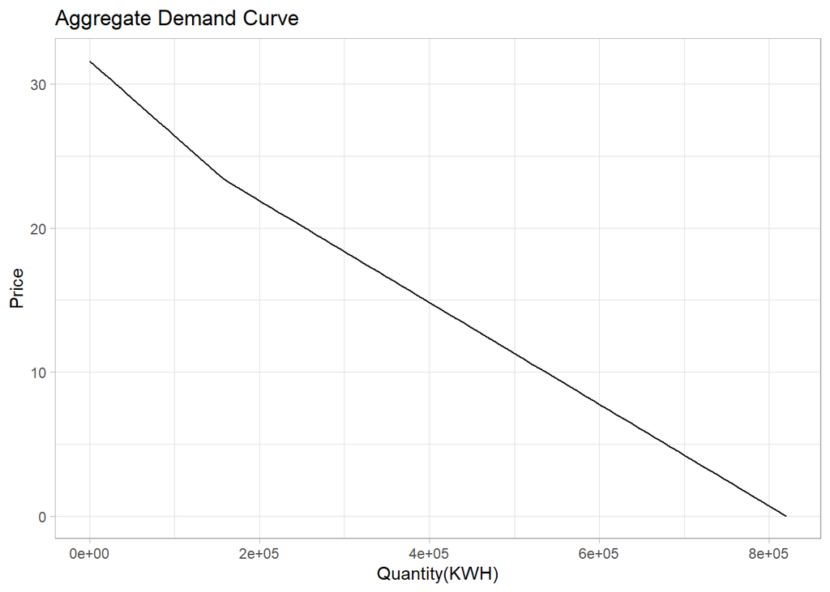

```r
price = seq(0, 31.6, length.out = 100)
Qagg <- map(price, demand_agg) %>% unlist()

df<- tibble(Qagg = Qagg, price = price)

ggplot(df, aes(Qagg, price)) +
  geom_line() +
  labs(title = "Aggregate Demand Curve", x = "Quantity(KWH)", y = "Price") +
  theme_light()
```

```r
# Calculate the supply curve for electricity. We know the current price is $0.10/kWh, and the MC electricity curve is linear and will pass through the 0 intercept.
# Therefore, the slope of the supply curve can be found by doing (y2-y1/x2-x2) using the points (0,0) and (demand_agg(10),10). The zeros cancel out so we get:

mpc_slope <- (10/(demand_agg(10)))

supply_p <- function(q){
  p <- mpc_slope*q
  return(q)
}

supply_q <- function(p){
  q <- (p/mpc_slope)
  return(q)
}
```

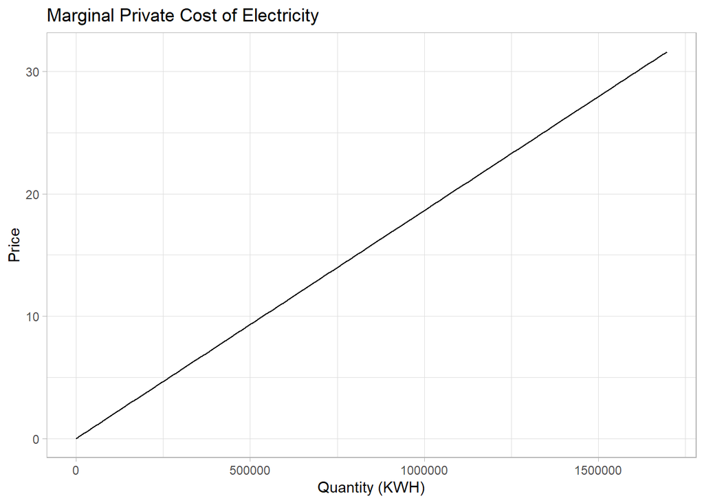

```r
supply_price = seq(0, 31.6, length.out = 100)
q_supply <- supply_q(price_high)

supply_something<- map(price_high,q_supply) %>% unlist()

df_4 <- tibble(q_supply = q_supply, supply_price = supply_price)

ggplot(df_4, aes(q_supply,supply_price)) +
  geom_line() +
  labs(title = "Marginal Private Cost of Electricity", x = "Quantity (KWH)", y = "Price") +
  theme_light()
```

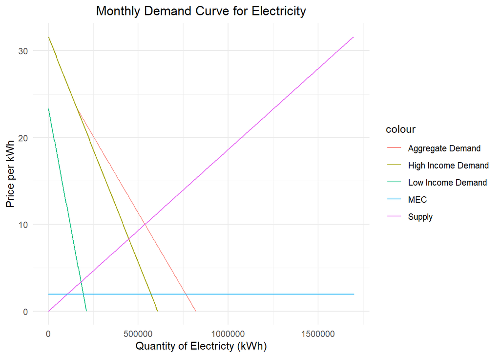

```r
ggplot() +
  geom_line(df, mapping=aes(Qagg, price, color = "Aggregate Demand"))+
  geom_line(df_2, mapping=aes(demand_low,price_low, color = "Low Income Demand")) +
  geom_line(df_3, mapping=aes(demand_high,price_high, color = "High Income Demand")) +
  geom_line(df_4, mapping=aes(q_supply,supply_price, color = "Supply"))+
  geom_segment(aes(x = 0, y = 1.97, xend = 1700000, yend = 1.97, color = "MEC"))+
  labs(x = "Quantity of Electricty (kWh)",
       y = "Price per kWh",
       title = "Monthly Demand Curve for Electricity") +
  theme_minimal() +
  theme(plot.title = element_text(hjust = 0.5))
```

The aggregate monthly demand curve for electricity is shown in red

What is the supply curve for electricity? - The supply curve for electricity is shown in purple and can be expressed by the equation

- P = 1.86^{-5}Q

```r
#Find the q free market value at the market equilibrium point
#We know that the free market is at equilibrium where p=10, because the current cost of electricity is 10 cents/kwh
Q_f <- demand_agg(10)
P_f <- 10
```

```r
# I also define functions for calculating the consumer surplus:

CS <- function(p, model){
  q <- demand(p, model)
  cs <- 0.5*(model$coefficients[[1]] - p)*q
  return(cs)
}

CS_agg <- function(p){
  cs <- CS(p,model_demand_l) + CS(p,model_demand_h)
  return(cs)
}
```

```r
#calculate benefit to consumers under status quo"

consumer_surplus_low <- CS(10,model_demand_l)
consumer_surplus_high <- CS(10,model_demand_h)

consumer_surplus_agg <- CS_agg(10)
```

```r
#function for MPC
MPC<- function(q){
  p <- mpc_slope*q
  return(p)
}

PS <- function(q){
  ps <- 0.5*(MPC(q))*q
  return(ps)
}
```

```r
producer_surplus_f <- PS(supply_q(10))
```

```r
#environmental cost
environmental_cost <- Q_f*1.97
```

The “benefit” to consumers under the status quo is $5.298722^{4} ($52,987)

The “benefit” to producers under the status quo is $2.683597^{4}

The environmental cost under the status quo is1.057337^{4}

# Question 3

How is the current consumer benefit divided between “high” and “low” income consumers?

```r
# Find the CS for each income group

cs_l <- CS(10, model_demand_l)
cs_h <- CS(10, model_demand_h)
```

High income consumers have higher benefit when compared to low income consumers.

- The consumer benefit for low income consumers is $8112.43.
- The consumer benefit for high income consumers is $4.487479^{4}.

# Question 4

4. Derive the optimal electricity tax (in cents per kWh) using the interim SCC. Noting that recent research has shown the poor face a disproportionate share of the impacts from climate change, assume that the climate externality is borne entirely by the “low” income group. What would be the effects of this tax on:
1. The amount of electricity produced and consumed
2. The price of electricity
3. Overall welfare of “high” income consumers
4. Overall welfare of “low” income consumers
5. Power suppliers (i.e., electricity producers)
6. Total environmental damage
7. Total tax revenue generated

```r
#First we need to find the marginal social cost including the externality

#the optimal tax is equal to the MEC. Therefore the Marginal social cost is just 1.96 cents

#Shift the aggregate demand curve down to account for tax.
```

```r
#demand_new_low <- function(p, model){
 # q <- (p - (model$coefficients[[1]]-t))/model$coefficients[[2]]
  #q <- ifelse(q<0,0,q)
  #return(q)
#}

demand_new<- function(p, model){
  q <- (p - (model$coefficients[[1]]-1.97))/model$coefficients[[2]]
  q <- ifelse(q<0,0,q)
  return(q)
}

demand_agg_new <- function(p){
  q <- demand_new(p, model_demand_l) + demand_new(p, model_demand_h)
  return(q)
}

demand_agg_new_eq <- function(q)(demand_new_low(p, model_demand_l) + demand(p, model_demand_h))
```

```r
#creating the data frame for the new
price_new = seq(0, 29.5, length.out = 100)
Qagg_new <- map(price_new, demand_agg_new) %>% unlist()

df_new <- tibble(Qagg_new = Qagg_new, price_new = price_new)
```

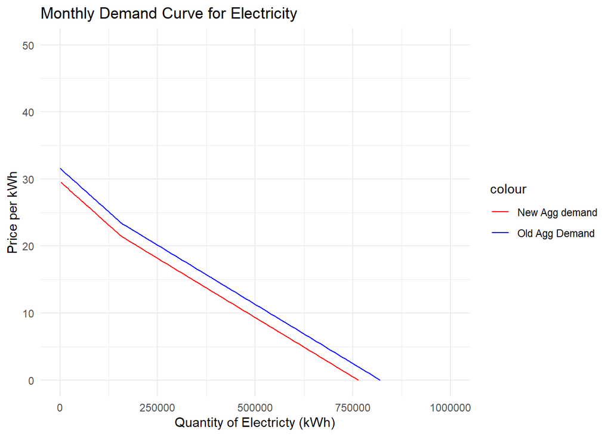

```r
#map the new demand curve and the old demand curve to make sure I did it right
ggplot() +
  geom_line(df, mapping=aes(Qagg, price, color = "Old Agg Demand"))+
  geom_line(df_new, mapping=aes(Qagg_new, price_new, color = "New Agg demand")) +
  scale_color_manual(values = c('red', 'blue')) +
  ylim(0,50) +
  xlim(0,1000000)+
  labs(x = "Quantity of Electricty (kWh)",
       y = "Price per kWh",
       title = "Monthly Demand Curve for Electricity") +
  theme_minimal()
```

```r
mpc_eq <- function(q)(mpc_slope*q)
```

```r
# First I need to find the new demand curve by shifting the aggregate demand curve down by the optimal tax

#demand-supply
#uniroot(function_you_write, c(0,600000))$root
```

```r
# First I need to find the new demand curve by shifting the aggregate demand curve down by the optimal tax. I did this to check that my function worked correctly
equilibrium_pt_free_mkt <- function(p)((demand(p, model_demand_l) + demand(p, model_demand_h))-(p/mpc_slope))
p_free_market <- uniroot(equilibrium_pt_free_mkt, c(0,700000))$root
q_free_market <- demand_agg(p_free_market)
```

```r
#calculating the intercept points
equilibrium_pt_tax_51 <- function(p)((demand_new(p, model_demand_l) + demand_new(p, model_demand_h))-(p/mpc_slope))
p_tax_51 <- uniroot(equilibrium_pt_tax_51, c(0,700000))$root

q_tax_51 <- demand_agg_new(p_tax_51)
```

**A:** The new amount of electricity produced/consumed under the tax is 5.0021643^{5} KWH. It decreased from status quo

**B:** The price of electricity under a tax is $0.1127 (11.27 cents) . (This is the new p equilibrium value plus the 1.97cent tax)

```r
# Writing a new function for  consumer surplus:

CS_new <- function(p, model){
  q <- demand_new(p, model)
  cs <- 0.5*(model$coefficients[[1]] - p)*q
  return(cs)
}

CS_agg <- function(p){
  cs <- CS_new(p,model_demand_l) + CS_new(p,model_demand_h)
  return(cs)
}
```

```r
#calculate the welfare effects to low and high income consumers
consumer_surplus_low_t_51 <- CS((p_tax_51+1.97),model_demand_l)
consumer_surplus_high_t_51 <- CS((p_tax_51+1.97),model_demand_h)


#however, low income consumers will bear the brunt of the environmental cost, so we need to calculate the total enviromental cost.

MEC <- 1.97

environmental_cost_t_51 <- MEC*q_tax_51

consumer_surplus_low_true <- consumer_surplus_low-environmental_cost_t_51
```

**C:** The overall welfare of “high” income consumers under a new tax is $3.967685^{4}. ($39676.85)

**D:** The overall welfare of “low” income consumers under a new tax is $6622.73. ($6622.73) *Side note: If we assume that low-income consumers bear the full cost of environmental damage associated with electricity production, then welfare was already negative before the tax was implemented.*

```r
PS <- function(q){
  ps <- 0.5*(MPC(q))*q
  return(ps)
}
# calculate the producer surplus
ps_change <- PS(q_tax_51)
```

**E:** Under a tax power suppliers will have a producer surplus of $2.3309801^{4} ($23309.80)

```r
#calculate environmental damage --> I did this already
```

**F:** Under a tax the total environmental damage be $9854.26 ($9854.26)

```r
#calculate tax revenue
tax_revenue_t_51 <- q_tax_51*1.97
```

**G:** The total tax revenue generated will be $9854.26. ($9854.26) The tax revenue generated is equivalent to the total environmental cost.

# Question 5

5. Now, assume that all revenue from the electricity tax will be redistributed to the consumers in proportion to their pre-tax consumption. For example, if 80% of the electricity was consumed by “high” income consumers, then they get 80% of the tax revenue. Additionally, consider the fact that current scientific evidence suggests the true SCC may be much higher than 51. For a range of SCC values (51, 75, 100, 125, and 150 per metric ton of CO2), calculate the effects of an SCC-based electricity tax on:
1. Overall welfare of “high” income consumers
2. Overall welfare of “low” income consumers
3. Electricity producers

```r
# Calculate electricity consumption before tax

low_consume <- demand(model_demand_l, p = 10)/((demand(model_demand_h, p = 10)) + demand(model_demand_l, p=10))
# 0.2260845 = 22.61%

high_consume <- demand(model_demand_h, p = 10)/((demand(model_demand_h, p = 10)) + demand(model_demand_l, p=10))
# 0.7739155 = 77.39%

#calculate the environmental cost
MEC_51 <- (1.97)
environmental_cost_t_51 <- MEC_51*q_tax_51

h_welfare <- (consumer_surplus_high_t_51 + high_consume * tax_revenue_t_51)
l_welfare <- ((consumer_surplus_low_t_51 + low_consume * tax_revenue_t_51) - environmental_cost_t_51)
ps_question5 <- ps_change
```

```r
# Create new data frame with the different price/kWh for different SCC values (I couldn't figure out how to do this, so I did it by hand below. I just know that we should, can someone help me please)

# Calculate the different price/kWh for different SCC values.
# $75/ton SCC value = $75/(2205lbs/$0.85) = $0.0289/kWh
# $100/ton SCC value = $100/(2205lbs/$0.85) = $0.0385/kWh
# $125/ton SCC value = $125/(2205lbs/$0.85) = $0.0482/kWh
# $150/ton SCC value = $150/(2205lbs/$0.85) = $0.0578/kWh

# price_scc_75 <- 2.89
# price_scc_100 <- 3.85
# price_scc_125 <- 4.82
# price_scc_150 <- 5.78
```

#### Social Cost of Carbon at $51/ton

**A:** The overall welfare to “high” income consumers is $4.730322^{4} ($47,303.22)

**B:** The overall welfare of “low” income consumers is $-1003.64

($-1,003.64). This indicates that for low income consumers there is a net loss.

**C:** The overall welfare to electricity producers is $2.3309801^{4} ($23,309.8)

#### Social Cost of Carbon at $75/ton

```r
# to calculate the "high" income consumers welfare under the tax rebate, it is CS + tax rebate

# I think these are the CS but I am struggling to find tax rebate. I know this code is not complete yet, I am just trying to figure things out.
price_CW_75 <- 2.89
price_CW_100 <- 3.85
price_CW_125 <- 4.82
price_CW_150 <- 5.78
```

```r
#write a new demand function where the social cost of carbon is $75 dollars a ton
demand_new_75<- function(p, model){
  q <- (p - (model$coefficients[[1]]-(price_CW_75)))/model$coefficients[[2]]
  q <- ifelse(q<0,0,q)
  return(q)
}

demand_agg_new_75 <- function(p){
  q <- demand_new_75(p, model_demand_l) + demand_new(p, model_demand_h)
  return(q)
}

equilibrium_pt_tax_75 <- function(p)((demand_new_75(p, model_demand_l) + demand_new_75(p, model_demand_h))-(p/mpc_slope))
p_tax_75 <- uniroot(equilibrium_pt_tax_75, c(0,700000))$root

q_tax_75 <- demand_agg_new_75(p_tax_51)

consumer_surplus_low_t_75 <- CS((p_tax_75+price_CW_75),model_demand_l)
consumer_surplus_high_t_75 <- CS((p_tax_75+price_CW_75),model_demand_h)

#calculate the tax revenue
tax_revenue_t_75 <- q_tax_75*(price_CW_75)

#calculate producer surplus
ps_t_75 <- PS(q_tax_75)

#calculate the environmental cost
MEC_75 <- (price_CW_75)
environmental_cost_t_75 <- MEC_75*q_tax_75


#use tax revnue and consumer surplus to
h_welfare_75 <- (consumer_surplus_high_t_75 + (high_consume * tax_revenue_t_75))
l_welfare_75 <- ((consumer_surplus_low_t_75 + low_consume * tax_revenue_t_75)-environmental_cost_t_75)
```

Under a $75 SCC:

**A:** The overall welfare to “high” income consumers is $4.836013^{4} ($48,360.13)

**B:** The overall welfare of “low” income consumers is $-5022.43

($-5,022.43)

**C:** The overall welfare to electricity producers is $2.2538162^{4} ($22,538.16)

#### Social Cost of Carbon at $100/ton

```r
#write a new demand function where the social cost of carbon is $100 dollars a ton
demand_new_100<- function(p, model){
  q <- (p - (model$coefficients[[1]]-(price_CW_100)))/model$coefficients[[2]]
  q <- ifelse(q<0,0,q)
  return(q)
}

demand_agg_new_100 <- function(p){
  q <- demand_new_100(p, model_demand_l) + demand_new_100(p, model_demand_h)
  return(q)
}

equilibrium_pt_tax_100 <- function(p)((demand_new_100(p, model_demand_l) + demand_new_100(p, model_demand_h))-(p/mpc_slope))
p_tax_100 <- uniroot(equilibrium_pt_tax_100, c(0,700000))$root

q_tax_100 <- demand_agg_new_100(p_tax_100)

consumer_surplus_low_t_100 <- CS((p_tax_100+price_CW_100),model_demand_l)
consumer_surplus_high_t_100 <- CS((p_tax_100+price_CW_100),model_demand_h)

#calculate the tax revenue
tax_revenue_t_100 <- q_tax_100*(price_CW_100)

#calculate producer surplus
ps_t_100 <- PS(q_tax_100)

#calculate the environmental cost
MEC_100 <- (price_CW_100)
environmental_cost_t_100 <- MEC_100*q_tax_100

#use tax revnue and consumer surplus to
h_welfare_100 <- (consumer_surplus_high_t_100 + high_consume * tax_revenue_t_100)
l_welfare_100 <- ((consumer_surplus_low_t_100 + low_consume * tax_revenue_t_100)-environmental_cost_t_100)
```

Under a $100 SCC:

**A:** The overall welfare to “high” income consumers is $4.888102^{4} ($48881.02)

**B:** The overall welfare of “low” income consumers is $-8524.49

($-8524.49)

**C:** The overall welfare to electricity producers is $2.0176231^{4} ($20176.23)

#### Social Cost of Carbon at $125/ton

```r
#write a new demand function where the social cost of carbon is $125 dollars a ton
demand_new_125 <- function(p, model){
  q <- (p - (model$coefficients[[1]]-(price_CW_125)))/model$coefficients[[2]]
  q <- ifelse(q<0,0,q)
  return(q)
}

demand_agg_new_125 <- function(p){
  q <- demand_new_125(p, model_demand_l) + demand_new_125(p, model_demand_h)
  return(q)
}

equilibrium_pt_tax_125 <- function(p)((demand_new_125(p, model_demand_l) + demand_new_125(p, model_demand_h))-(p/mpc_slope))
p_tax_125 <- uniroot(equilibrium_pt_tax_125, c(0,700000))$root

q_tax_125 <- demand_agg_new_125(p_tax_125)

consumer_surplus_low_t_125 <- CS((p_tax_125+price_CW_125),model_demand_l)
consumer_surplus_high_t_125 <- CS((p_tax_125+price_CW_125),model_demand_h)

#calculate the tax revenue
tax_revenue_t_125 <- q_tax_125*(price_CW_125)

#calculate producer surplus
ps_t_125 <- PS(q_tax_125)

#calculate the environmental cost
MEC_125 <- (price_CW_125)
environmental_cost_t_125 <- MEC_125*q_tax_125

#use tax revnue and consumer surplus to
h_welfare_125 <- (consumer_surplus_high_t_125 + high_consume * tax_revenue_t_125)
l_welfare_125 <- ((consumer_surplus_low_t_125 + low_consume * tax_revenue_t_125)-environmental_cost_t_125)
```

Under a $125 SCC:

**A:** The overall welfare to “high” income consumers is $4.941258^{4} ($49,412.58)

**B:** The overall welfare of “low” income consumers is $-1.195471^{4}

($-11954.71)

**C:** The overall welfare to electricity producers is $1.8647865^{4} ($18647.87)

#### Social Cost of Carbon at $150/ton

```r
#write a new demand function where the social cost of carbon is $150 dollars a ton
demand_new_150<- function(p, model){
  q <- (p - (model$coefficients[[1]]-(price_CW_150)))/model$coefficients[[2]]
  q <- ifelse(q<0,0,q)
  return(q)
}

demand_agg_new_150 <- function(p){
  q <- demand_new_150(p, model_demand_l) + demand_new_150(p, model_demand_h)
  return(q)
}

equilibrium_pt_tax_150 <- function(p)((demand_new_150(p, model_demand_l) + demand_new_150(p, model_demand_h))-(p/mpc_slope))
p_tax_150 <- uniroot(equilibrium_pt_tax_150, c(0,700000))$root

q_tax_150 <- demand_agg_new_150(p_tax_150)

consumer_surplus_low_t_150 <- CS((p_tax_150+price_CW_150),model_demand_l)
consumer_surplus_high_t_150 <- CS((p_tax_150+price_CW_150),model_demand_h)

#calculate the tax revenue
tax_revenue_t_150 <- q_tax_150*(price_CW_150)

#calculate producer surplus
ps_t_150 <- PS(q_tax_150)

#calculate the environmental cost
MEC_150 <- (price_CW_150)
environmental_cost_t_150 <- MEC_150*q_tax_150

#use tax revnue and consumer surplus to
h_welfare_150 <- (consumer_surplus_high_t_150 + high_consume * tax_revenue_t_150)
l_welfare_150 <- ((consumer_surplus_low_t_150 + low_consume * tax_revenue_t_150)- environmental_cost_t_150)
```

Under a $150 SCC:

**A:** The overall welfare to “high” income consumers is $4.974932^{4} ($49,749.32)

**B:** The overall welfare of “low” income consumers is $-1.504783^{4}

($-15047.83)

**C:** The overall welfare to electricity producers is $1.7194517^{4} ($17,194.52)

# Question 6

6. Suppose the “high” income group has access to expensive home solar generation. This lowers the electricity demand curve for the “high” income group by half (vertically). Under this new demand:
1. What is total electricity consumption?

```r
#Half the intercept of the demand function to lower the demand curve for the high income group by half.
demand_new_solar<- function(p, model){
  q <- (p - (.5*model$coefficients[[1]]))/model$coefficients[[2]]
  q <- ifelse(q<0,0,q)
  return(q)
}

#new agg demand function accounting for solar
demand_agg_new_solar <- function(p){
  q <- demand(p, model_demand_l) + demand_new_solar(p, model_demand_h)
  return(q)
}

equilibrium_pt_tax_solar <- function(p)((demand(p, model_demand_l) + demand_new_solar(p, model_demand_h))-(p/mpc_slope))
p_solar <- uniroot(equilibrium_pt_tax_solar, c(0,700000))$root

q_solar <- demand_agg_new_solar(p_solar)
```

**A:** The total electricity consumption is 3.3779613^{5}kwh.

2. What is the total environmental externality?

```r
environmental_cost_solar<- MEC*q_solar
```

**B:** The total electricity environmental externality is $6654.58.

3. What value of the electricity tax makes the total environmental damage the same as the damage when solar panels are available to the high income group?

```r
# rearrange to solve for p with the half demand function
demand_new_solar_p <- function(q, model){
  p <- (q*model$coefficients[[2]])+(0.5*model$coefficients[[1]])
  p <- ifelse(p<0,0,p)
  return(p)
}

#rearrange to solve for p with the demand curve
demand_p <- function(q, model){
  p <- (q*model$coefficients[[2]])+(model$coefficients[[1]])
  p <- ifelse(p<0,0,p)
  return(p)
}

demand_agg_new_solar_p <- function(q){
  p <- demand_p(q, model_demand_l) + demand_new_solar_p(q, model_demand_h)
  return(p)
}

demand_agg_p <- function(q){
  p <- demand_p(q, model_demand_l) + demand_p(q, model_demand_h)
  return(p)
}

diff <- demand_agg_p(q_solar) - demand_agg_new_solar_p(q_solar)
```

**C:** The value of the electricity tax that makes the total environmental damage the same as the damage when solar panels are available to the high income group is $14.0354961 cents. I got this by taking the difference between the original aggregate demand curve and the aggregate demand curve accounting for the halved demand of high income groups because of access to solar panels at the new equilibrium q point (which was found using the new aggregate demand curve )

**Note to grader:** I’m so sorry…we tried so hard and did our best…but we’ve been working on it for so long and I think we just need to call it at this point.